# First Data Analysis Project

The objective of this project is to determine the top locations in the southeast region of Brazil to extract solar and wind energy. In addition, it would be beneficial to forecast future solar and wind conditions to estimate potential energy production.

## 1.0 Obtain Data

- Data has been collected from the following website:  
  https://www.kaggle.com/PROPPG-PPG/hourly-weather-surface-brazil-southeast-region
- As a reference, the following table includes the list of columns with their description:

| Label | Description |
| --- | --- |
| wsid | Weather station id |
| wsnm | Name station (usually city location or nickname) |
| elvt | Elevation |
| lat | Latitude |
| lon | Longitude |
| inme | Station number (INMET number) for the location |
| city | City |
| prov | State (Province) |
| mdct | Observation Datetime (complete date: date + time) |
| date | Date of observation |
| yr | The year (2000-2016) |
| mo | The month (0-12) |
| da | The day (0-31) |
| hr | The hour (0-23) |
| prcp | Amount of precipitation in millimetres (last hour) |
| stp | Air pressure for the hour in hPa to tenths (instant) |
| smax | Maximum air pressure for the last hour in hPa to tenths |
| smin | Minimum air pressure for the last hour in hPa to tenths |
| gbrd | Solar radiation KJ/m2 |
| temp | Air temperature (instant) in celsius degrees |
| dewp | Dew point temperature (instant) in celsius degrees |
| tmax | Maximum temperature for the last hour in celsius degrees |
| dmax | Maximum dew point temperature for the last hour in celsius degrees |
| tmin | Minimum temperature for the last hour in celsius degrees |
| dmin | Minimum dew point temperature for the last hour in celsius degrees |
| hmdy | Relative humid in % (instant) |
| hmax | Maximum relative humid temperature for the last hour in % |
| hmin | Minimum relative humid temperature for the last hour in % |
| wdsp | Wind speed in metres per second |
| wdct | Wind direction in radius degrees (0-360) |
| gust | Wind gust in metres per second |

### 1.1 Read in Data to Pandas DataFrame

```python
import pandas as pd
import numpy as np
import matplotlib.pyplot as plt
import seaborn as sns
import statsmodels.api as sm

from sklearn.metrics import mean_squared_error
from math import sqrt
from statsmodels.tsa.api import ExponentialSmoothing, SimpleExpSmoothing, Holt
from IPython.display import display

df = pd.read_csv('sudeste.csv')
```

## 2.0 Clean and Explore Data

### 2.1 Data Type

Get a feel for the data format **.head()** and type **.info()**.

```python
pd.set_option('display.max_columns', None)
df.head(5)
```

|  | wsid | wsnm | elvt | lat | lon | inme | city | prov | mdct | date | yr | mo | da | hr | prcp | stp | smax | smin | gbrd | temp | dewp | tmax | dmax | tmin | dmin | hmdy | hmax | hmin | wdsp | … |
| --- | --- | --- | --- | --- | --- | --- | --- | --- | --- | --- | --- | --- | --- | --- | --- | --- | --- | --- | --- | --- | --- | --- | --- | --- | --- | --- | --- | --- | --- | --- |
| 0 | 178 | SÃO GONÇALO | 237.0 | -6.835777 | -38.311583 | A333 | São Gonçalo | RJ | 2007-11-06 00:00:00 | 2007-11-06 | 2007 | 11 | 6 | 0 | NaN | 982.5 | 982.5 | 981.3 | NaN | 29.3 | 12.1 | 29.7 | 16.8 | 25.5 | 10.8 | 35.0 | 58.0 | 32.0 | 3.2 | … |
| 1 | 178 | SÃO GONÇALO | 237.0 | -6.835777 | -38.311583 | A333 | São Gonçalo | RJ | 2007-11-06 01:00:00 | 2007-11-06 | 2007 | 11 | 6 | 1 | NaN | 983.2 | 983.2 | 982.5 | NaN | 29.0 | 13.5 | 29.9 | 13.6 | 29.0 | 12.2 | 39.0 | 39.0 | 35.0 | 3.6 | … |
| 2 | 178 | SÃO GONÇALO | 237.0 | -6.835777 | -38.311583 | A333 | São Gonçalo | RJ | 2007-11-06 02:00:00 | 2007-11-06 | 2007 | 11 | 6 | 2 | NaN | 983.5 | 983.5 | 983.2 | NaN | 27.4 | 14.0 | 29.0 | 14.0 | 27.4 | 13.6 | 44.0 | 44.0 | 39.0 | 2.5 | … |
| 3 | 178 | SÃO GONÇALO | 237.0 | -6.835777 | -38.311583 | A333 | São Gonçalo | RJ | 2007-11-06 03:00:00 | 2007-11-06 | 2007 | 11 | 6 | 3 | NaN | 983.7 | 983.7 | 983.4 | NaN | 25.8 | 16.9 | 27.4 | 16.9 | 25.8 | 14.1 | 58.0 | 58.0 | 44.0 | 1.7 | … |
| 4 | 178 | SÃO GONÇALO | 237.0 | -6.835777 | -38.311583 | A333 | São Gonçalo | RJ | 2007-11-06 04:00:00 | 2007-11-06 | 2007 | 11 | 6 | 4 | NaN | 983.7 | 983.8 | 983.6 | NaN | 25.4 | 16.4 | 26.3 | 17.0 | 25.3 | 16.4 | 57.0 | 58.0 | 56.0 | 3.1 | … |

```python
df.info()
```

```
<class 'pandas.core.frame.DataFrame'>
RangeIndex: 9779168 entries, 0 to 9779167
Data columns (total 31 columns):
 #   Column  Dtype
---  ------  -----
 0   wsid    int64
 1   wsnm    object
 2   elvt    float64
 3   lat     float64
 4   lon     float64
 5   inme    object
 6   city    object
 7   prov    object
 8   mdct    object
 9   date    object
```

[output cut: 23 more lines]

### 2.2 Remove Unwanted Columns

Don't need the stations name 'wsnm' or station number 'inme' just use stations id 'wsid'. For now we don't need location of the station so remove 'elvt', 'lat', 'lon','city', 'prov'. Can get the date and time from 'mdct' so remove the following column 'date' 'yr', 'mo', 'da', 'hr'.  
Use **.drop()** to remove columns.

Takes too long to run .drop() so commented it out.  
Alternatively you could create a list of columns that you would want to read in from the start.

```python
# df.drop(['wsnm', 'inme', 'elvt', 'lat', 'lon', 'city', 'prov', 'date', 'yr', 'mo', 'da', 'hr'], axis=1)
```

### 2.3 Change Index

Change the index from integer to Observation Datetime (mdct) **.set_index()** and change the data type from object to datetime **.to_datetime()** since we will be performing time series analysis.

```python
df = df.set_index('mdct')
df.index = pd.to_datetime(df.index)
```

### 2.4 Getting A Description Of The Data

Looking at the minimum row from **Out[6]**, columns prcp, stp, smax, smin, gbrd, hmdy, hmax, hmin, wdsp, wdct and gust have zero as a value so there could be missing data.

- **Out[7]** Shows a large amount of zeros that must be investigated. Maybe weather station is offline for these inputs.
- **Out[8]** Shows that there are 122 unique values for wsnm so this means that there are 122 weather stations.
- **Out[9]** Create a list of all weather stations by Weather Station ID.

```python
# Describe specific columns where there are only numbers.
df.describe(include =[np.number])
```

|  | wsid | elvt | lat | lon | yr | mo | da | hr | prcp | stp | smax | smin | gbrd | temp | dewp | tmax | dmax | tmin | dmin | hmdy | hmax | hmin | wdsp | wdct | gust |
| --- | --- | --- | --- | --- | --- | --- | --- | --- | --- | --- | --- | --- | --- | --- | --- | --- | --- | --- | --- | --- | --- | --- | --- | --- | --- |
| count | 9.779168e+06 | 9.779168e+06 | 9.779168e+06 | 9.779168e+06 | 9.779168e+06 | 9.779168e+06 | 9.779168e+06 | 9.779168e+06 | 1.407984e+06 | 9.779168e+06 | 9.779168e+06 | 9.779168e+06 | 5.670348e+06 | 9.779137e+06 | 9.778693e+06 | 9.779142e+06 | 9.778858e+06 | 9.779134e+06 | 9.778361e+06 | 9.779168e+06 | 9.779156e+06 | 9.779124e+06 | 8.853607e+06 | 9.779168e+06 | 9.462694e+06 |
| mean | 3.592531e+02 | 5.940923e+02 | -2.023082e+01 | -4.464590e+01 | 2.011164e+03 | 6.521960e+00 | 1.575465e+01 | 1.150000e+01 | 9.366544e-01 | 8.804292e+02 | 8.803034e+02 | 8.798331e+02 | 1.176371e+03 | 2.047423e+01 | 1.472681e+01 | 2.110503e+01 | 1.524025e+01 | 1.986418e+01 | 1.422089e+01 | 6.726667e+01 | 6.996991e+01 | 6.441965e+01 | 1.998156e+00 | 1.385991e+02 | 4.494015e+00 |
| std | 3.901630e+01 | 3.980379e+02 | 3.172643e+00 | 4.882117e+00 | 3.207774e+00 | 3.425538e+00 | 8.802154e+00 | 6.922190e+00 | 2.923291e+00 | 2.482650e+02 | 2.489171e+02 | 2.487716e+02 | 1.138754e+03 | 7.331125e+00 | 5.805413e+00 | 7.545549e+00 | 5.866811e+00 | 7.134849e+00 | 5.777089e+00 | 2.654213e+01 | 2.643371e+01 | 2.656550e+01 | 1.618531e+00 | 1.052018e+02 | 2.981790e+00 |
| min | 1.780000e+02 | 0.000000e+00 | -2.496282e+01 | -5.667732e+01 | 2.000000e+03 | 1.000000e+00 | 1.000000e+00 | 0.000000e+00 | 0.000000e+00 | 0.000000e+00 | 0.000000e+00 | 0.000000e+00 | 0.000000e+00 | -3.800000e+00 | -1.000000e+01 | -3.200000e+00 | -1.000000e+01 | -8.500000e+00 | -1.000000e+01 | 0.000000e+00 | 0.000000e+00 | 0.000000e+00 | 0.000000e+00 | 0.000000e+00 | 0.000000e+00 |
| 25% | 3.280000e+02 | 2.830000e+02 | -2.239580e+01 | -4.743410e+01 | 2.009000e+03 | 4.000000e+00 | 8.000000e+00 | 5.000000e+00 | 0.000000e+00 | 9.113000e+02 | 9.115000e+02 | 9.110000e+02 | 6.500000e+01 | 1.770000e+01 | 1.210000e+01 | 1.820000e+01 | 1.270000e+01 | 1.720000e+01 | 1.160000e+01 | 5.300000e+01 | 5.800000e+01 | 4.900000e+01 | 8.000000e-01 | 5.600000e+01 | 2.300000e+00 |
| 50% | 3.580000e+02 | 5.730000e+02 | -2.075041e+01 | -4.445378e+01 | 2.011000e+03 | 7.000000e+00 | 1.600000e+01 | 1.200000e+01 | 0.000000e+00 | 9.442000e+02 | 9.444000e+02 | 9.439000e+02 | 8.634270e+02 | 2.140000e+01 | 1.610000e+01 | 2.190000e+01 | 1.660000e+01 | 2.080000e+01 | 1.560000e+01 | 7.400000e+01 | 7.800000e+01 | 7.000000e+01 | 1.700000e+00 | 1.140000e+02 | 4.200000e+00 |
| 75% | 3.940000e+02 | 8.750000e+02 | -1.891707e+01 | -4.243575e+01 | 2.014000e+03 | 9.000000e+00 | 2.300000e+01 | 1.800000e+01 | 6.000000e-01 | 9.731000e+02 | 9.733000e+02 | 9.728000e+02 | 2.103000e+03 | 2.490000e+01 | 1.890000e+01 | 2.580000e+01 | 1.940000e+01 | 2.420000e+01 | 1.840000e+01 | 8.900000e+01 | 9.100000e+01 | 8.600000e+01 | 2.900000e+00 | 2.160000e+02 | 6.300000e+00 |
| max | 4.230000e+02 | 1.758000e+03 | 0.000000e+00 | 0.000000e+00 | 2.016000e+03 | 1.200000e+01 | 3.100000e+01 | 2.300000e+01 | 1.000000e+02 | 1.050000e+03 | 1.050000e+03 | 1.050000e+03 | 1.158649e+04 | 4.490000e+01 | 4.270000e+01 | 4.500000e+01 | 4.480000e+01 | 4.500000e+01 | 4.490000e+01 | 1.000000e+02 | 1.000000e+02 | 1.000000e+02 | 1.980000e+01 | 3.600000e+02 | 5.000000e+01 |

```python
# Find the total number of times zero appears in each column.
(df.iloc [: , 13:30]==0 ).sum()
```

```
prcp    746679
stp     701723
smax    705438
smin    705358
gbrd    879490
temp    628611
dewp    705849
tmax    631473
dmax    706613
tmin    631410
dmin    714946
hmdy    679673
hmax    677458
hmin    684793
wdsp    828184
wdct    870382
gust    841180
dtype: int64
```

```python
# Describe specific columns where there are only strings.
df.describe(include =['O'])
```

|  | wsnm | inme | city | prov | date |
| --- | --- | --- | --- | --- | --- |
| count | 9779168 | 9779168 | 9779168 | 9779168 | 9779168 |
| unique | 122 | 121 | 117 | 4 | 5974 |
| top | ECOLOGIA AGRÍCOLA | A620 | Rio de Janeiro | MG | 2016-08-20 |
| freq | 143376 | 160584 | 302352 | 4710632 | 2928 |

```python
# Create array to see all the weather stations.
ws_list=df.wsid.unique().tolist()
print(ws_list)
```

```
[178, 303, 304, 305, 306, 307, 308, 309, 310, 311, 312, 313, 314, 315, 316, 317, 318, 319, 320, 321, 322, 323, 324, 325, 326, 327, 328, 329, 330, 331, 332, 333, 334, 335, 336, 337, 338, 339, 340, 341, 342, 343, 344, 345, 346, 347, 348, 349, 350, 351, 352, 353, 354, 355, 356, 357, 358, 359, 360, 361,…
```

### 2.5 Selecting Weather Station

Since the data set is so large lets save calculation time by add an input function to ask what weather station we want to look at.

Enter **314**.

```python
station_id_input = int(input("Weather Station ID: "))
```

```
Weather Station ID: 314
```

```python
# Create df of chosen  weather station.
selected_station = df['wsid'] == station_id_input
data_ws = df[selected_station]
```

### 2.6 Weather Station Offline

Create a list when 'prcp' to 'gust' columns are equal to zero and assume the weather station was offline since all values are equal to zero.

- **Out[13]** Shows total number of zeros for each column.
- **Out[14]** Shows total number of zeros after dropping indexes when the weather station was assumed offline.

As you can see the number of zeros has dropped significantly. However, there are still a lot of zeros in the Solar Radiation column so let's explore that next.

```python
ws_shutdown_list = data_ws[(data_ws['prcp']==0) & (data_ws['stp']==0) & (data_ws['smax']==0) & (data_ws['smin']==0) & (data_ws['temp']==0) &
                                       (data_ws['dewp']==0) & (data_ws['tmax']==0) & (data_ws['dmax']==0) & (data_ws['tmin']==0)& (data_ws['dmin']==0)& (data_ws['hmdy']==0) &
                                       (data_ws['hmax']==0) & (data_ws['hmin']==0) & (data_ws['wdsp']==0) & (data_ws['wdct']==0)& (data_ws['gust']==0)].index.tolist()
data_ws_online =data_ws.drop(ws_shutdown_list)
```

```python
# Weather station with both online and offline values.
(data_ws.iloc [:, 13:30]==0 ).sum()
```

```
prcp    10198
stp     10154
smax    10201
smin    10201
gbrd    38859
temp    10156
dewp    10156
tmax    10159
dmax    10159
tmin    10159
dmin    10159
hmdy    10157
hmax    10158
hmin    10160
wdsp    10216
wdct    10216
gust    10224
dtype: int64
```

```python
# Weather station with only online values.
(data_ws_online.iloc [:, 13:30]==0 ).sum()
```

```
prcp       44
stp         0
smax       47
smin       47
gbrd    32965
temp        2
dewp        2
tmax        5
dmax        5
tmin        5
dmin        5
hmdy        3
hmax        4
hmin        6
wdsp       62
wdct       62
gust       70
dtype: int64
```

### 2.7 Correct Solar Radiation Data

Plot solar radiation VS time to see where the sources of zeros are coming from.

- **Out[15]** Found a large source of zeros at the start of the data series so maybe the weather station were not collecting solar radiation value.
- **Out[16]** Zoomed in at a two week time period we can see that data is not being collected at certain time which makes sense because there is very little solar energy at night.

Turn the Null data to zero to in order to perform forecasting later on **In[17]**.

- **Out[18]** See that Null have turned to zero.

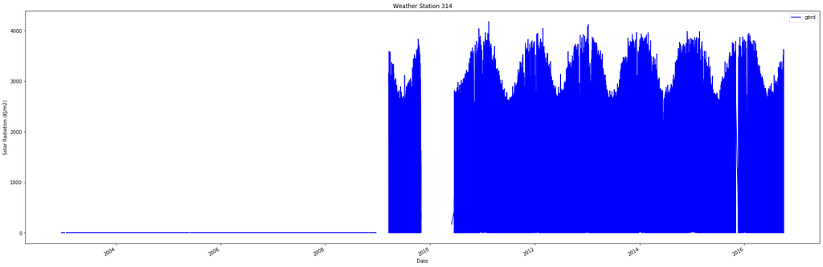

```python
# Plot total time series of solar radiation
plot_start_date=data_ws_online.index[0]
plot_end_date=data_ws_online.index[-1]

data_ws_online_range = data_ws_online.loc[plot_start_date :plot_end_date]
data_ws_online_range = data_ws_online_range.reset_index()
ax=data_ws_online_range.plot(x='mdct', y='gbrd', figsize=(30, 10),color='blue')
ax.set_ylabel('Solar Radiation (KJ/m2)')
ax.set_title('Weather Station ' + str(station_id_input))
ax.set_xlabel('Date')
```

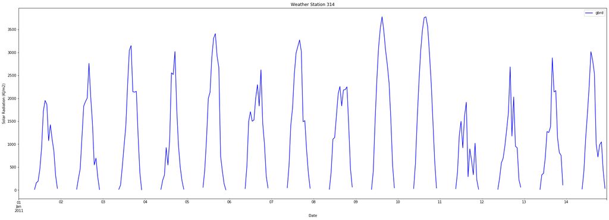

```python
# Plot two weeks time series of solar radiation
plot_start_date_2='2011-1-1'
plot_end_date_2='2011-1-14'

data_ws_online_range = data_ws_online.loc[plot_start_date_2 :plot_end_date_2]
data_ws_online_range = data_ws_online_range.reset_index()
ax=data_ws_online_range.plot(x='mdct', y='gbrd', figsize=(30, 10),color='blue')
ax.set_ylabel('Solar Radiation (KJ/m2)')
ax.set_title('Weather Station ' + str(station_id_input))
ax.set_xlabel('Date')
```

```python
# When solar radiation is Null turn it to zero
solar_radiation = data_ws_online[['gbrd']].copy()
solar_radiation['gbrd'].fillna(0,inplace=True)
```

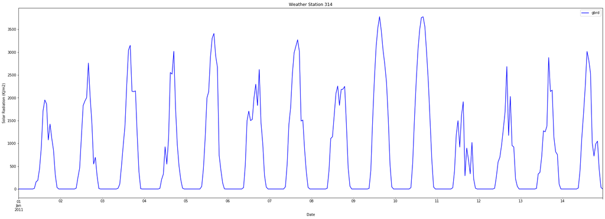

```python
# Plot two weeks time series of solar radiation with Null turned to zero
solar_radiation_range = solar_radiation.loc[plot_start_date_2 :plot_end_date_2]
solar_radiation_range = solar_radiation_range.reset_index()
ax=solar_radiation_range.plot(x='mdct', y='gbrd', figsize=(30, 10),color='blue')
ax.set_ylabel('Solar Radiation (KJ/m2)')
ax.set_title('Weather Station ' + str(station_id_input))
ax.set_xlabel('Date')
```

### 2.8 Correct Wind Data

Let's check if there is any missing data in the wind speed collection.

- **Out[19]** There are 4850 missing so these should be removed to perform forecasts later on.
- **In[20]** Interpolate wind speed data when Null.
- **Out[21]** After interpolating there are no longer any missing values.

```python
#Count number of missing values.
data_ws_online.wdsp.isna().sum()
```

```
4850
```

```python
#Interpolate missing values.
data_ws_online_wind=data_ws_online.copy()
data_ws_online_wind['wdsp'].interpolate('linear', limit_direction='both', inplace=True)
```

```python
#Count number of missing values after interpolation.
data_ws_online_wind.wdsp.isna().sum()
```

```
0
```

### 2.9 Clean Up The Data Set

Second step is to set solar radiation from Null to zero as per section 2.7 **In[24]**.

- **Out[25]** As you can see there are no longer any missing values for solar radiation.

The last step is to interpolate the wind speed as per section 2.8 **In[24]**.

- **Out[26]** Demonstrates that wind speed has been corrected. The blue segments shows when the wind speed was equal to zero.

```python
df_online = df[((df['prcp']!=0) & (df['stp']!=0) & (df['smax']!=0) & (df['smin']!=0) & (df['temp']!=0) &
                                       (df['dewp']!=0) & (df['tmax']!=0) & (df['dmax']!=0) & (df['tmin']!=0)& (df['dmin']!=0)& (df['hmdy']!=0) &
                                       (df['hmax']!=0) & (df['hmin']!=0) & (df['wdsp']!=0) & (df['wdct']!=0)& (df['gust']!=0))]
```

```python
(df_online.iloc [: , 13:30]==0 ).sum()
```

```
prcp         0
stp          0
smax         0
smin         0
gbrd    512378
temp         0
dewp         0
tmax         0
dmax         0
tmin         0
dmin         0
hmdy         0
hmax         0
hmin         0
wdsp         0
wdct         0
gust         0
dtype: int64
```

```python
df_online_corc1= df_online.copy()
df_online_corc1['gbrd'].fillna(0,inplace=True)


df_online_corc2 = df_online_corc1.copy()
df_online_corc2['wdsp'].interpolate('linear',limit_direction='both', inplace=True)

df_online_corrected = df_online_corc2.copy()
df_online_corrected['gust'].interpolate('linear',limit_direction='both', inplace=True)
```

```python
df_online_corrected.isna().sum()
```

```
wsid          0
wsnm          0
elvt          0
lat           0
lon           0
inme          0
city          0
prov          0
date          0
yr            0
mo            0
da            0
hr            0
prcp    7976896
stp           0
smax          0
smin          0
gbrd          0
temp         23
dewp        412
tmax         18
dmax        239
tmin         23
dmin        740
hmdy          0
hmax          0
hmin          0
wdsp          0
wdct          0
gust          0
dtype: int64
```

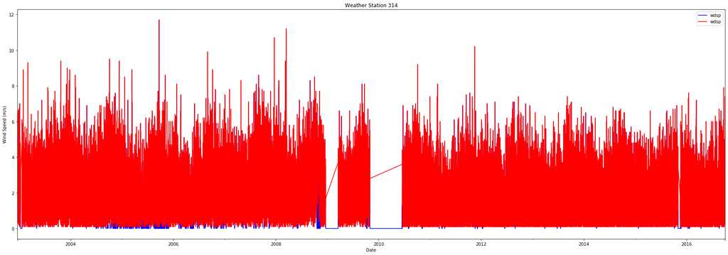

```python
selected_station2 = df_online_corrected['wsid'] == station_id_input
df_online_ws_corrected = df_online_corrected[selected_station2]

plot_start_date=data_ws.index[0]
plot_end_date=data_ws.index[-1]

data_ws_range = data_ws.loc[plot_start_date :plot_end_date]
data_ws_range = data_ws_range.reset_index()
ax=data_ws_range.plot(x='mdct', y='wdsp', figsize=(30, 10),color='blue')

df_online_ws_corrected_range = df_online_ws_corrected.loc[plot_start_date :plot_end_date]
df_online_ws_corrected_range = df_online_ws_corrected_range.reset_index()
df_online_ws_corrected_range.plot(x='mdct', y='wdsp', figsize=(30, 10), ax=ax,color='red')
ax.set_ylabel('Wind Speed (m/s)')
ax.set_xlabel('Date')
ax.set_title('Weather Station ' + str(station_id_input))
```

## 3.0 Analysis

### 3.1 Group Data by Weather Station

Find three weather stations for both highest solar radiation and highest wind speed.

Solar Radiation - Stations 178, 334, 356  
Wind Speed - Stations 370, 379, 375

```python
df_wsid =df_online_corrected.groupby('wsid')
```

```python
# Find the mean solar radiation and wind speed for each weather station and then rank them.
df_wsid_mean=df_wsid.mean()
df_wsid_mean['Solar_Radiation_Ranking'] = df_wsid_mean['gbrd'].rank(ascending=False)
df_wsid_mean['Wind_Speed_Ranking'] = df_wsid_mean['wdsp'].rank(ascending=False)
df_wsid_mean.sort_values('Solar_Radiation_Ranking', inplace = True)
df_wsid_mean.rename(columns={'gbrd':'Solar_Radiation_Avg(kJ/m2)'}, inplace=True)
df_wsid_mean[['Solar_Radiation_Avg(kJ/m2)']].round(1).head(10)
```

| wsid | Solar_Radiation_Avg(kJ/m2) |
| --- | --- |
| 178 | 992.1 |
| 334 | 921.8 |
| 356 | 896.9 |
| 347 | 892.1 |
| 355 | 891.8 |
| 352 | 889.0 |
| 351 | 880.2 |
| 353 | 868.5 |
| 350 | 861.5 |
| 346 | 852.6 |

```python
df_wsid_mean.sort_values('Wind_Speed_Ranking', inplace = True)
df_wsid_mean.rename(columns={'wdsp':'Wind_Speed_Avg(m/s)'}, inplace=True)
df_wsid_mean[['Wind_Speed_Avg(m/s)']].round(1).head(10)
```

| wsid | Wind_Speed_Avg(m/s) |
| --- | --- |
| 370 | 5.4 |
| 379 | 4.7 |
| 375 | 4.4 |
| 363 | 4.0 |
| 418 | 3.8 |
| 383 | 3.7 |
| 309 | 3.7 |
| 372 | 3.4 |
| 376 | 3.2 |
| 345 | 3.1 |

### 3.2 Top Solar Radiation Weather Stations

Plot the top three weather stations based on solar radiation.  
The results show that there is a seasonal trend which we will take a closer look at in section 3.4.

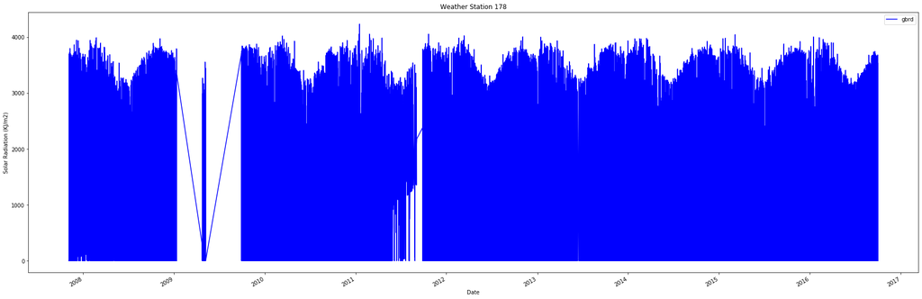

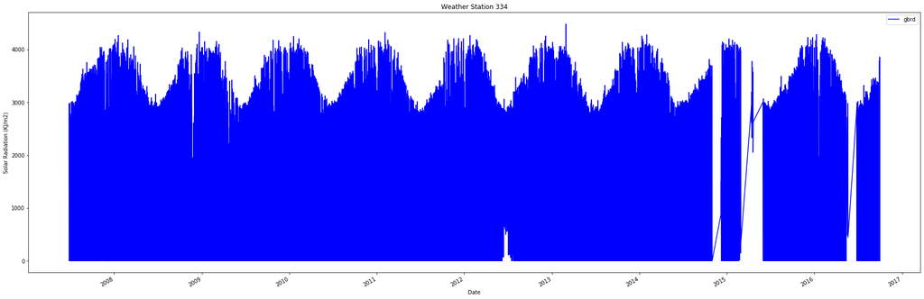

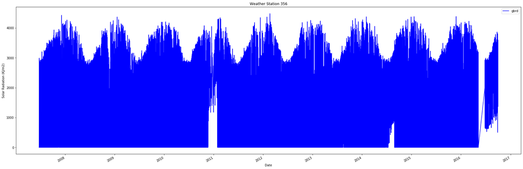

```python
selected_station_gbrd1 = df_online_corrected['wsid'] == 178
selected_station_gbrd2 = df_online_corrected['wsid'] == 334
selected_station_gbrd3 = df_online_corrected['wsid'] == 356

df_online_ws_corrected_gbrd1 = df_online_corrected[selected_station_gbrd1 ]
df_online_ws_corrected_gbrd2 = df_online_corrected[selected_station_gbrd2 ]
df_online_ws_corrected_gbrd3 = df_online_corrected[selected_station_gbrd3 ]

plot_start_date1=df_online_ws_corrected_gbrd1.index[0]
plot_end_date1=df_online_ws_corrected_gbrd1.index[-1]
plot_start_date2=df_online_ws_corrected_gbrd2.index[0]
plot_end_date2=df_online_ws_corrected_gbrd2.index[-1]
plot_start_date3=df_online_ws_corrected_gbrd3.index[0]
plot_end_date3=df_online_ws_corrected_gbrd3.index[-1]

df_online_ws_corrected_gbrd1_range =df_online_ws_corrected_gbrd1.loc[plot_start_date1 :plot_end_date1]
df_online_ws_corrected_gbrd1_range = df_online_ws_corrected_gbrd1_range.reset_index()
ax=df_online_ws_corrected_gbrd1_range.plot(x='mdct', y='gbrd', figsize=(30, 10),color='blue')
ax.set_ylabel('Solar Radiation (KJ/m2)')
ax.set_xlabel('Date')
ax.set_title('Weather Station 178' )


df_online_ws_corrected_gbrd2_range =df_online_ws_corrected_gbrd2.loc[plot_start_date2 :plot_end_date2]
df_online_ws_corrected_gbrd2_range = df_online_ws_corrected_gbrd2_range.reset_index()
ax=df_online_ws_corrected_gbrd2_range.plot(x='mdct', y='gbrd', figsize=(30, 10),color='blue')
ax.set_ylabel('Solar Radiation (KJ/m2)')
ax.set_xlabel('Date')
ax.set_title('Weather Station 334')

df_online_ws_corrected_gbrd3_range =df_online_ws_corrected_gbrd3.loc[plot_start_date3 :plot_end_date3]
df_online_ws_corrected_gbrd3_range = df_online_ws_corrected_gbrd3_range.reset_index()
ax=df_online_ws_corrected_gbrd3_range.plot(x='mdct', y='gbrd', figsize=(30, 10),color='blue')
ax.set_ylabel('Solar Radiation (KJ/m2)')
ax.set_xlabel('Date')
ax.set_title('Weather Station 356')
```

### 3.3 Top Wind Speed Weather Stations

Plot the top three weather stations based on wind speed.  
The results show that there is a seasonal trend which we will take a closer look at in section 3.4.

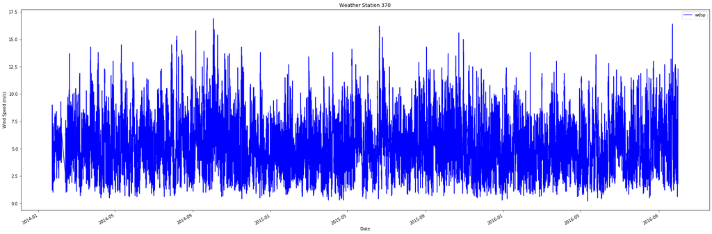

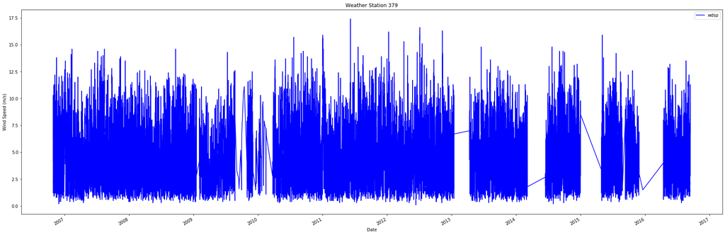

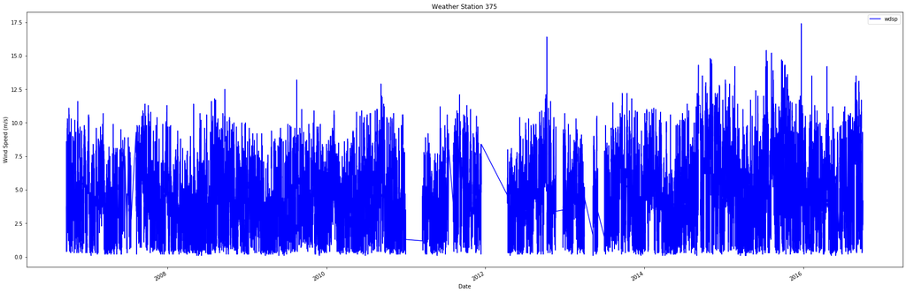

```python
selected_station_wdsp1 = df_online_corrected['wsid'] == 370
selected_station_wdsp2 = df_online_corrected['wsid'] == 379
selected_station_wdsp3 = df_online_corrected['wsid'] == 375

df_online_ws_corrected_wdsp1 = df_online_corrected[selected_station_wdsp1 ]
df_online_ws_corrected_wdsp2 = df_online_corrected[selected_station_wdsp2 ]
df_online_ws_corrected_wdsp3 = df_online_corrected[selected_station_wdsp3 ]

plot_start_date1=df_online_ws_corrected_wdsp1.index[0]
plot_end_date1=df_online_ws_corrected_wdsp1.index[-1]
plot_start_date2=df_online_ws_corrected_wdsp2.index[0]
plot_end_date2=df_online_ws_corrected_wdsp2.index[-1]
plot_start_date3=df_online_ws_corrected_wdsp3.index[0]
plot_end_date3=df_online_ws_corrected_wdsp3.index[-1]

df_online_ws_corrected_wdsp1_range =df_online_ws_corrected_wdsp1.loc[plot_start_date1 :plot_end_date1]
df_online_ws_corrected_wdsp1_range = df_online_ws_corrected_wdsp1_range.reset_index()
ax=df_online_ws_corrected_wdsp1_range.plot(x='mdct', y='wdsp', figsize=(30, 10),color='blue')
ax.set_ylabel('Wind Speed (m/s)')
ax.set_xlabel('Date')
ax.set_title('Weather Station 370')


df_online_ws_corrected_wdsp2_range =df_online_ws_corrected_wdsp2.loc[plot_start_date2 :plot_end_date2]
df_online_ws_corrected_wdsp2_range = df_online_ws_corrected_wdsp2_range.reset_index()
ax=df_online_ws_corrected_wdsp2_range.plot(x='mdct', y='wdsp', figsize=(30, 10),color='blue')
ax.set_ylabel('Wind Speed (m/s)')
ax.set_xlabel('Date')
ax.set_title('Weather Station 379')

df_online_ws_corrected_wdsp3_range =df_online_ws_corrected_wdsp3.loc[plot_start_date3 :plot_end_date3]
df_online_ws_corrected_wdsp3_range = df_online_ws_corrected_wdsp3_range.reset_index()
ax=df_online_ws_corrected_wdsp3_range.plot(x='mdct', y='wdsp', figsize=(30, 10),color='blue')
ax.set_ylabel('Wind Speed (m/s)')
ax.set_xlabel('Date')
ax.set_title('Weather Station 375')
```

### 3.4 Evaluate Seasonal Patterns

Use box plots to determine if there is a seasonal trend to help choose what forecasting method to use to predict wind speeds and solar radiation.

#### 3.4.1 Solar Radiation Seasonal Patterns

We can see that in the winter months (Southern Hemisphere) solar radiation drops which makes sense since the amount a day time decreases in the winter.

```python
pd.to_datetime(df_online_ws_corrected_gbrd1.mo, format='%m')
pd.to_datetime(df_online_ws_corrected_gbrd2.mo, format='%m')
pd.to_datetime(df_online_ws_corrected_gbrd3.mo, format='%m');
```

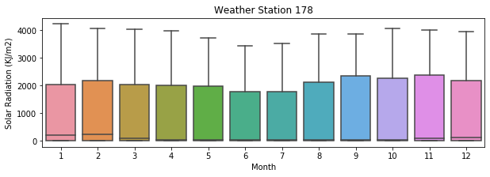

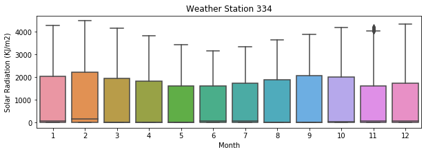

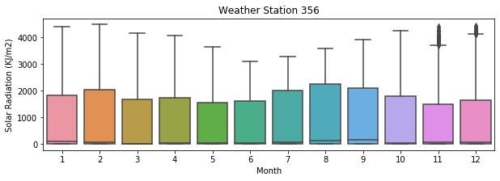

```python
fig, axes = plt.subplots(1,1, figsize=(10,3), sharex=True)
ax=sns.boxplot(data= df_online_ws_corrected_gbrd1, x='mo', y ='gbrd')
ax.set_ylabel('Solar Radiation (KJ/m2)')
ax.set_xlabel('Month')
ax.set_title('Weather Station 178' )

fig, axes = plt.subplots(1,1, figsize=(10,3), sharex=True)
ax=sns.boxplot(data= df_online_ws_corrected_gbrd2, x='mo', y ='gbrd')
ax.set_ylabel('Solar Radiation (KJ/m2)')
ax.set_xlabel('Month')
ax.set_title('Weather Station 334')

fig, axes = plt.subplots(1,1, figsize=(10,3), sharex=True)
ax=sns.boxplot(data= df_online_ws_corrected_gbrd3, x='mo', y ='gbrd')
ax.set_ylabel('Solar Radiation (KJ/m2)')
ax.set_xlabel('Month')
ax.set_title('Weather Station 356')
```

#### 3.4.2 Wind Speed Seasonal Patterns

Seems that in the fall (Southern Hemisphere) the wind speeds drop and then increase in the spring.

```python
pd.to_datetime(df_online_ws_corrected_wdsp1.mo, format='%m')
pd.to_datetime(df_online_ws_corrected_wdsp2.mo, format='%m')
pd.to_datetime(df_online_ws_corrected_wdsp3.mo, format='%m');
```

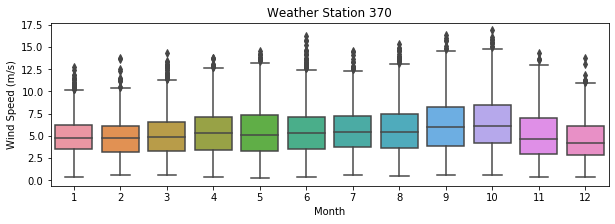

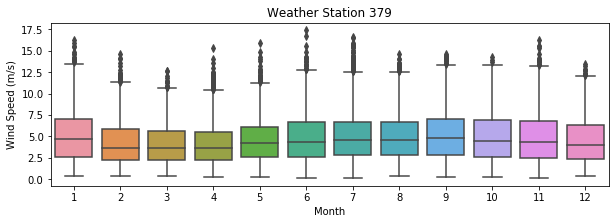

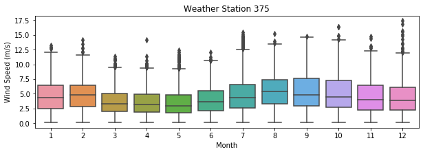

```python
fig, axes = plt.subplots(1,1, figsize=(10,3), sharex=True)
ax=sns.boxplot(data= df_online_ws_corrected_wdsp1, x='mo', y ='wdsp')
ax.set_ylabel('Wind Speed (m/s)')
ax.set_xlabel('Month')
ax.set_title('Weather Station 370')

fig, axes = plt.subplots(1,1, figsize=(10,3), sharex=True)
ax=sns.boxplot(data= df_online_ws_corrected_wdsp2, x='mo', y ='wdsp')
ax.set_ylabel('Wind Speed (m/s)')
ax.set_xlabel('Month')
ax.set_title('Weather Station 379')

fig, axes = plt.subplots(1,1, figsize=(10,3), sharex=True)
ax=sns.boxplot(data= df_online_ws_corrected_wdsp3, x='mo', y ='wdsp')
ax.set_ylabel('Wind Speed (m/s)')
ax.set_xlabel('Month')
ax.set_title('Weather Station 375')
```

# Experimenting with Forecasting

Since there is a seasonal trend we are going to use Holt-Winters forecasting technique. Created a User Defined Function to forecast solar radiation and wind speed for a specified weather stations.

```python
def SolarRadiationForecast(dataframe):

    # Test date runs for one year
    start_train_date = dataframe.index[0]
    end_train_date =dataframe.index[-8735]
    start_test_date=dataframe.index[-8736]
    end_test_date = dataframe.index[-1]

    train =dataframe[start_train_date : end_train_date]
    test =dataframe[start_test_date : end_test_date]

    data_forecast_gbrd1=dataframe.resample('D').mean()
    data_forecast_gbrd1['gbrd'].fillna(data_forecast_gbrd1['gbrd'].mean(), inplace=True)
    train=train.resample('D').mean()
    train['gbrd'].fillna(train['gbrd'].mean(), inplace=True)
    test=test.resample('D').mean()
    test['gbrd'].fillna(test['gbrd'].mean(), inplace=True)

    # Plot1 Training and test data
    ax=train.gbrd.plot(figsize=(15,8),color='blue')
    ax.set_ylabel('Solar Radiation (KJ/m2)')
    test.gbrd.plot(figsize=(15,8),color='green', ax=ax)
    ax.set_xlabel('Date')
    ax.legend(['Training Data','Test Data'])
    plt.title('Weather Station 334')

     # Plot2 Seasonal Data
    sm.tsa.seasonal_decompose(train.gbrd).plot()
    result = sm.tsa.stattools.adfuller(train.gbrd)
    plt.show(  )

    # Plot3 Forecast
    holt_avg=test.copy()
    fit1=ExponentialSmoothing(np.asarray(train['gbrd']), seasonal_periods =365, trend= 'add',seasonal= 'add').fit()
    holt_avg['Holt_Winter'] = fit1.forecast(len(test))
    plt.figure(figsize=(15,15))
    ax=plt.plot(train['gbrd'], label = 'Train Data',color='blue')
    plt.plot(test['gbrd'], label = 'Test Data',color='green')
    plt.plot(holt_avg['Holt_Winter'], label = 'Holt Winter Model',color='red')
    plt.legend()
    plt.ylabel('Solar Radiation (KJ/m2)')
    plt.xlabel('Date')
    plt.title('Weather Station 334')
    rms = sqrt(mean_squared_error(test.gbrd, holt_avg.Holt_Winter))
    print('RMS: ' ,rms)

    return
```

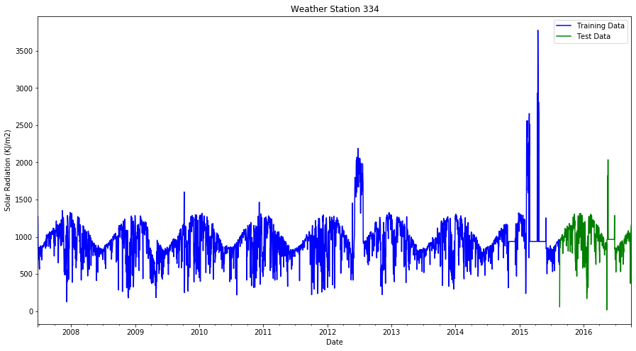

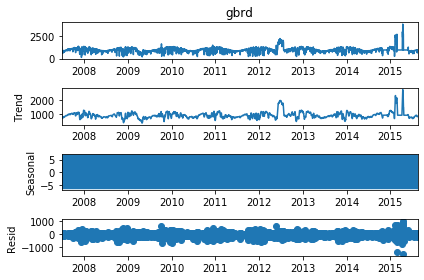

```
RMS:  232.33471597019317
```

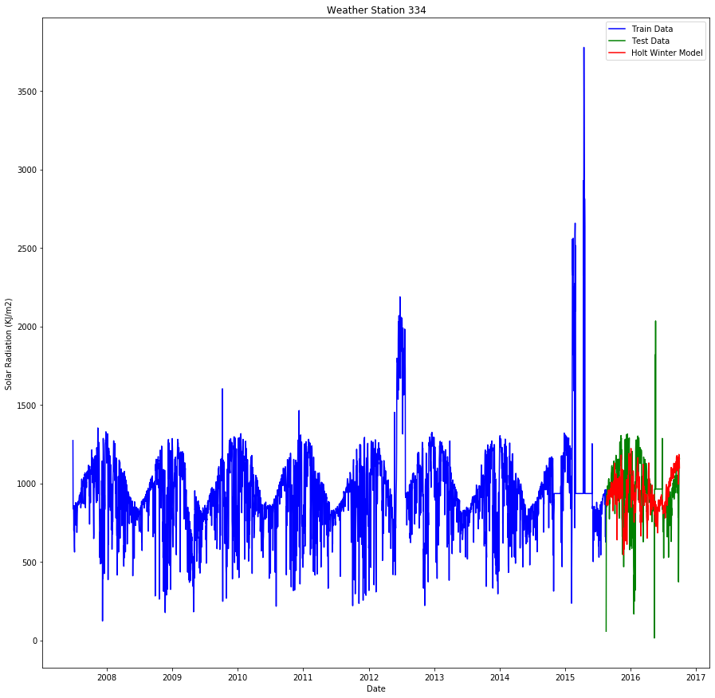

```python
import warnings
warnings.filterwarnings("ignore")
SolarRadiationForecast(dataframe=df_online_ws_corrected_gbrd2)
```

```python
def WindSpeedForecast(dataframe):

    # Test date runs for one year
    start_train_date = dataframe.index[0]
    end_train_date =dataframe.index[-8759]
    start_test_date=dataframe.index[-8760]
    end_test_date = dataframe.index[-1]

    train =dataframe[start_train_date : end_train_date]
    test =dataframe[start_test_date : end_test_date]

    data_forecast_wdsp=dataframe.resample('D').mean()
    data_forecast_wdsp['wdsp'].fillna(data_forecast_wdsp['wdsp'].mean(), inplace=True)
    train=train.resample('D').mean()
    train['wdsp'].fillna(train['wdsp'].mean(), inplace=True)
    test=test.resample('D').mean()
    test['wdsp'].fillna(test['wdsp'].mean(), inplace=True)

    #Plot1 Training and test data
    ax= train.wdsp.plot(figsize=(15,8),color='blue')
    ax.set_ylabel('Wind Speed (m/s)')
    test.wdsp.plot(figsize=(15,8),ax=ax,color='green')
    ax.set_xlabel('Date')
    ax.legend(['Training Data','Test Data'])
    plt.title('Weather Station 334')

    #Plot2 Seasonal Data
    sm.tsa.seasonal_decompose(train.wdsp).plot()
    result = sm.tsa.stattools.adfuller(train.wdsp)
    plt.show()

    #Plot3 Forecast
    holt_avg=test.copy()
    fit1=ExponentialSmoothing(np.asarray(train['wdsp']), seasonal_periods =365, trend= 'add',seasonal= 'add').fit()
    holt_avg['Holt_Winter'] = fit1.forecast(len(test))
    plt.figure(figsize=(15,15))
    plt.plot(train['wdsp'], label = 'Train Data',color='blue')
    plt.plot(test['wdsp'], label = 'Test Data',color='green')
    plt.plot(holt_avg['Holt_Winter'], label = 'Holt_Winter',color='red')
    plt.legend()
    plt.ylabel('Wind Speed (m/s)')
    plt.xlabel('Date')
    plt.title('Weather Station 334')
    rms = sqrt(mean_squared_error(test.wdsp, holt_avg.Holt_Winter))
    print('RMS: ' ,rms)

    return
```

[figure not shown]

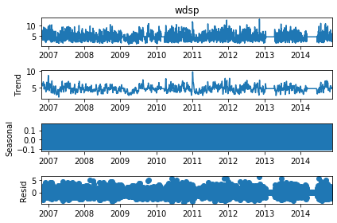

```
RMS:  1.8909099649813201
```

[figure not shown]

```python
WindSpeedForecast(dataframe=df_online_ws_corrected_wdsp2)
```

### As you may see from the results of forecasting there is quite a bit of noise that needs to be address. This was my first attempt at forecasting and there is a lot more for me to learn and advance this skill.